# Praca domowa 2

Pawel Glowinski

## Dane

Dane wykorzystane w Pracy domowej 2 opisują wycenę nieruchmości. Każda obserwacja jest pewną nieruchmością, która posiada informacje takie jak powierzchnia, liczba pokoi, liczba łazienek i wiele więcj. Opis wszystkich kolumn w pliku `README.md`.

## Zadanie 1

Jak wygląda rozkład ceny nieruchomości w poszczególnych kodach pocztowych na przestrzeni lat? Rozważamy kody pocztowe, które mają więcej niż 280 posiadłości.

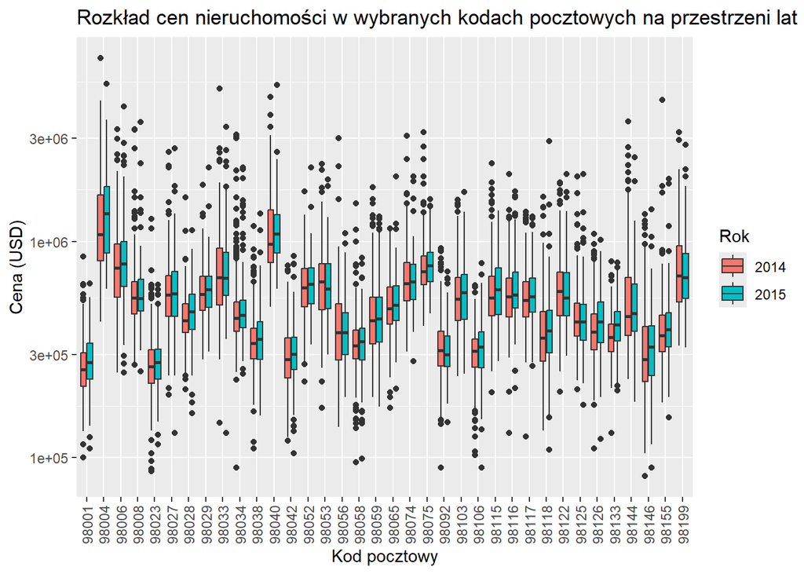

```r
  df %>%
  group_by(zipcode) %>%
  mutate(count_zip = n(),Year = substr(date,1,4)) %>%
  filter(count_zip>280) %>%
  ggplot(aes(x = as.factor(zipcode),y = price,fill = Year))+
  geom_boxplot()+
  scale_y_log10()+
  labs(title = "Rozkład cen nieruchomości w wybranych kodach pocztowych na przestrzeni lat",x="Kod pocztowy",y="Cena (USD)",fill = "Rok")+
  scale_x_discrete(guide = guide_axis(angle = 90))
```

**Komentarz:** Na przestrzeni lat ceny nieruchomości nie zmieniły się znacząco w poszczególnych lokalizacjach. Możemy natomiast zauważyć różnice w cenach miedzy kodami pocztowymi.

## Zadanie 2

Czy jest różnica w rozkładzie ceny nierchomości od powierzchni mieszkalnej uwzględniając podział na nieruchomości z piwnicą i bez?

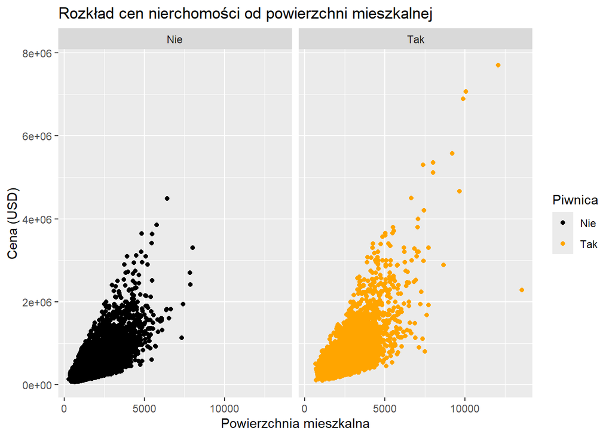

```r
answer2 <- df %>%
  mutate(piwnica = case_when(sqft_basement==0 ~"Nie",
                                 sqft_basement>0 ~"Tak"))
ggplot(answer2,aes(x = sqft_living,y = price, colour =  piwnica))+
  geom_point()+
  scale_color_manual(values = c("black","orange"))+
  facet_wrap(~piwnica)+
  labs(title = "Rozkład cen nierchomości od powierzchni mieszkalnej",x = "Powierzchnia mieszkalna",y = "Cena (USD)",colour="Piwnica")
```

**Komentarz:** Nie ma różnicy w rozkładzie cen nierchomości od powierzchni mieszkalnej między nieruchomościami z piwnicą i bez.

## Zadanie 3

Jaka jest zależność pomiędzy jakością wykończenia nieruchomości a liczbą pięter?

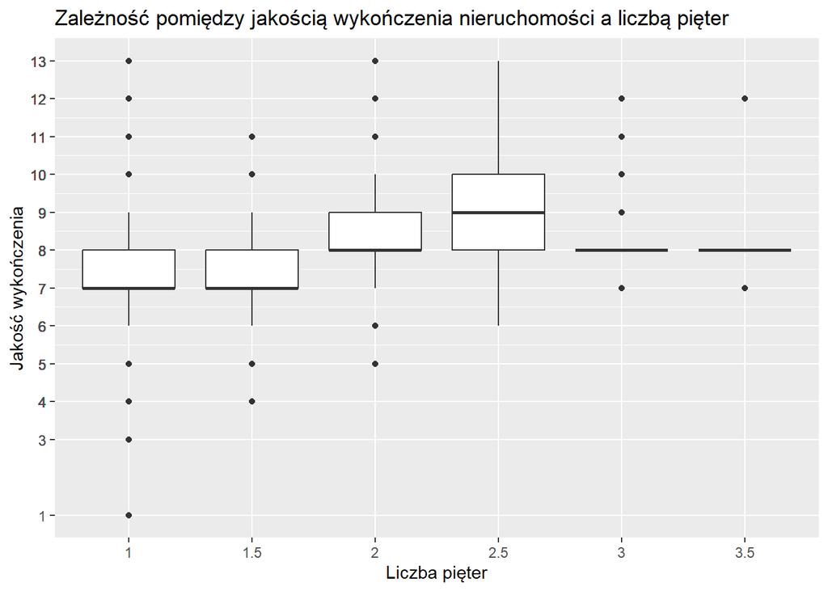

```r
ggplot(df,aes(x = factor(floors),y = grade))+
  geom_boxplot()+
  labs(title = "Zależność pomiędzy jakością wykończenia nieruchomości a liczbą pięter", x = "Liczba pięter", y = "Jakość wykończenia")+
  scale_y_continuous(breaks = df$grade)
```

**Komentarz:** Im wyższa liczba pięter tym wyższa jakość wykończenia, zwłaszcza podnosi się minimalny poziom wykończenia. Dla 3 i 3,5 pięter jest za mało danych, jednak można zauważyć kontynuacje trendu.

## Zadanie 4

Jaka jest zależność między powierzchnią mieszkalną nieruchomości a powierzchnią gruntu w podziale na liczbę sypialni?

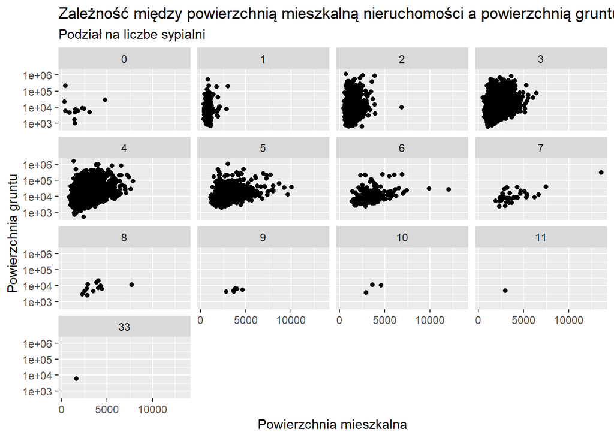

```r
ggplot(df,aes(y = sqft_lot,x = sqft_living))+
  geom_point()+
  facet_wrap(~bedrooms)+
  labs(title = "Zależność między powierzchnią mieszkalną nieruchomości a powierzchnią gruntu",subtitle = "Podział na liczbe sypialni",x="Powierzchnia mieszkalna",y="Powierzchnia gruntu")+
  scale_y_log10()+
  scale_x_continuous()
```

**Komentarz:**Nie ma znaczącej zależności między powierzchnią mieszkalną nieruchomości a powierzchnią gruntu.

## Zadanie 5

Rozważmy tylko nieruchomości, które miały remont. W której dekadzie było najwięcej przeprowadzonych remontów? Czy w poszczególnych dekadach jest porównywalny procent nieruchmości dla każdej wartości miary jakości i wykończenia nieruchomości?

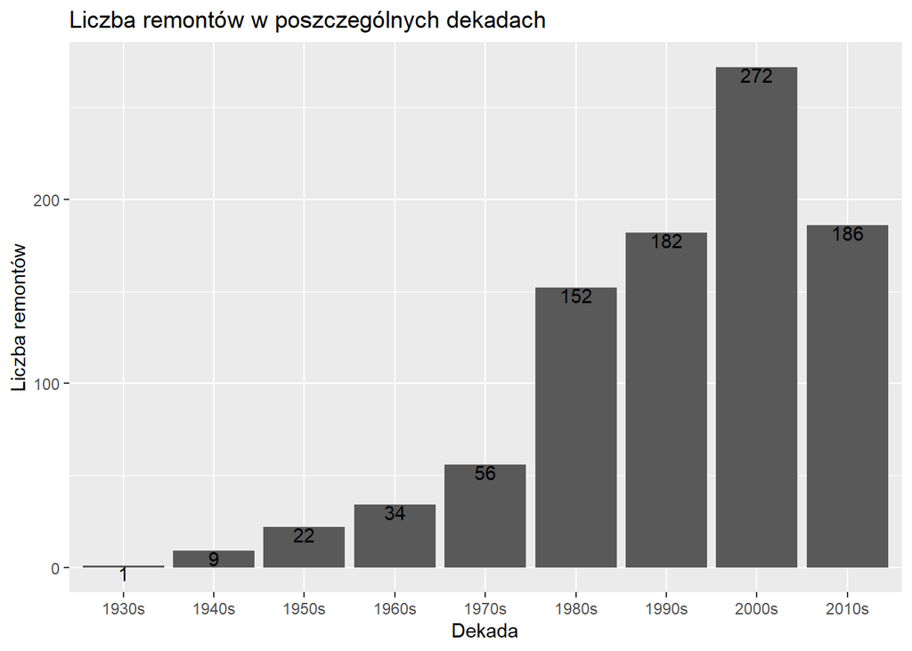

```r
answer5 <- df %>%
  filter(yr_renovated!=0) %>%
  mutate(rok_remont = substr(yr_renovated,3,4),dekada = case_when((0<=rok_remont & rok_remont<10) ~ "2000s",
                                                                  (10<=rok_remont & rok_remont<20) ~ "2010s",
                                                                  (30<=rok_remont & rok_remont<40) ~ "1930s",
                                                                  (40<=rok_remont & rok_remont<50) ~ "1940s",
                                                                  (50<=rok_remont & rok_remont<60) ~ "1950s",
                                                                  (60<=rok_remont & rok_remont<70) ~ "1960s",
                                                                  (70<=rok_remont & rok_remont<80) ~ "1970s",
                                                                  (80<=rok_remont & rok_remont<90) ~ "1980s",
                                                                  (90<=rok_remont & rok_remont<=99) ~ "1990s")) %>%
  group_by(dekada) %>%
  mutate(dekada_count = n())

ggplot(answer5,aes(dekada))+
  geom_bar()+
  labs(title = "Liczba remontów w poszczególnych dekadach",x="Dekada",y="Liczba remontów")+
  geom_text(aes(label = after_stat(count)), stat = "count",vjust=1,hjust=0.5, colour = "black")
```

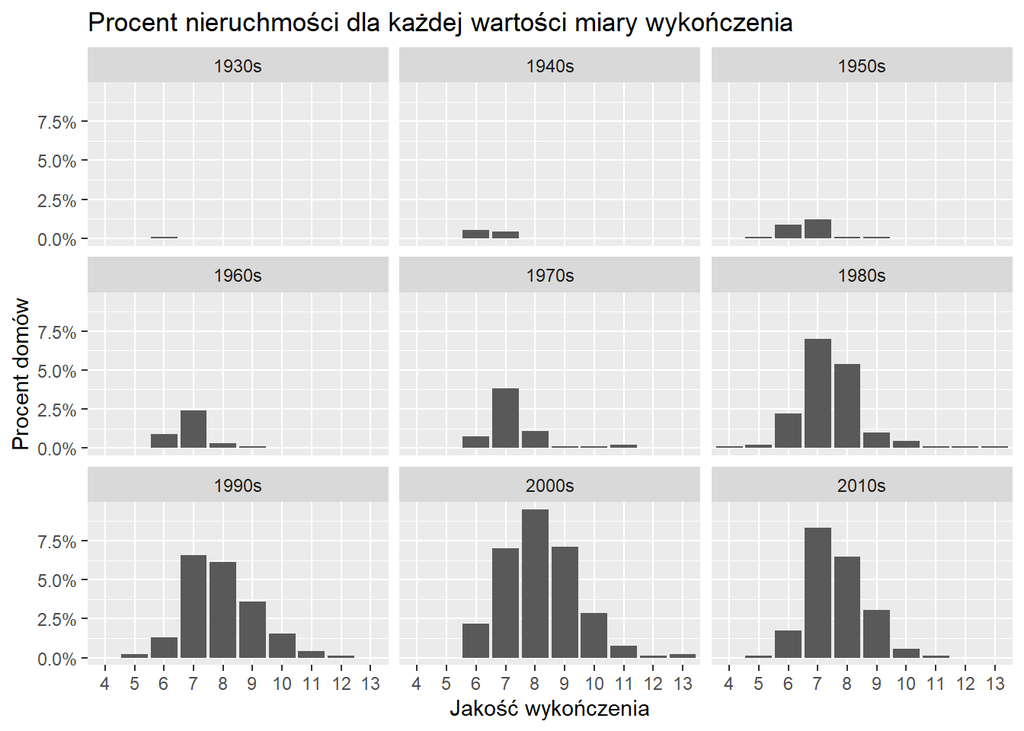

```r
ggplot(answer5,aes(x = as.factor(grade), y = after_stat(count/sum(count))))+
  geom_bar()+
  facet_wrap(~dekada)+
  scale_y_continuous(labels = scales::percent)+
  labs(title = "Procent nieruchmości dla każdej wartości miary wykończenia",x="Jakość wykończenia",y="Procent domów")
```

**Komentarz:** Najwięcej domów wyremontowano w latach 2000. W poszczególnych dekadach procent nieruchomości nie jest porównywalny dla każdej wartości miary. Zazwyczaj największy udział mają domy o poziomie wykończenia 7,8,9 natomiast najmniejszy udział o miarach 4,5,12,13. (100% to wszystkie wyremontowane nieruchomości we wszytkich latach)

## Zadanie 6

Jak prezentuje się wartość minimalna, średnia i maksymalna ceny nieruchmości w podziele na rok budowy nieruchomości.

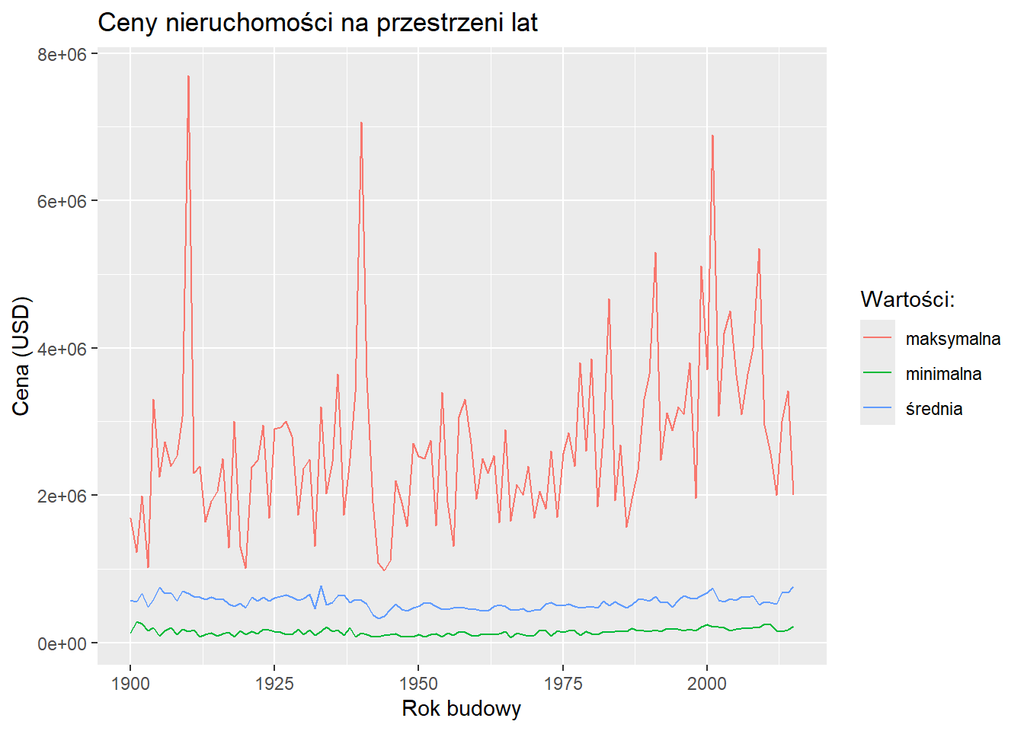

```r
answer6 <- df %>%
  group_by(yr_built) %>%
  summarise(minimalna = min(price), średnia = mean(price), maksymalna = max(price)) %>%
  pivot_longer(c(minimalna, średnia, maksymalna), names_to = "rodzaj", values_to = "cena")

ggplot(answer6,aes(yr_built,cena,colour = rodzaj))+
  geom_line()+
  labs(title = "Ceny nieruchomości na przestrzeni lat",x = "Rok budowy",y = "Cena (USD)", colour = "Wartości:")
```

**Komentarz:** Wartość minimalna i średnia utrzymują względnie stały poziom na przestrzeni lat. Natomiast wartość maksymalna zmienia się często i drastycznie.